# MSA8190 - HW5

Kristen Biskobing

October 11, 2016

### Problem 1

The percentage of cotton in material used to manufacture mens shirts follows.

```r
df <- as.matrix(read.xlsx("HW5_data.xlsx",sheetIndex = 1))
```

#### (a) Compute the sample mean, variance and median.

```r
mu<-mean(df)
var<-var(df)
med<-median(df)
mu
```

```
## [1] 34.79844
```

```r
var[1]
```

```
## [1] 1.860791
```

```r
med
```

```
## [1] 34.7
```

#### (b) Construct a stem-and-leaf display for the data.

```r
stem(df)
```

```
##
##   The decimal point is at the |
##
##   32 | 156789
##   33 | 11456666688
##   34 | 011122355666667777779
##   35 | 00111234456789
##   36 | 2346888
##   37 | 13689
```

#### (c) Construct a frequency distribution and histogram for the cotton content.

```r
factordf<-factor(cut(df, breaks=c(32, 33, 34, 35, 36, 37, 38)))
dffd<-as.data.frame(table(factordf))
dffd
```

```
##   factordf Freq
## 1  (32,33]    6
## 2  (33,34]   12
## 3  (34,35]   22
## 4  (35,36]   12
## 5  (36,37]    7
## 6  (37,38]    5
```

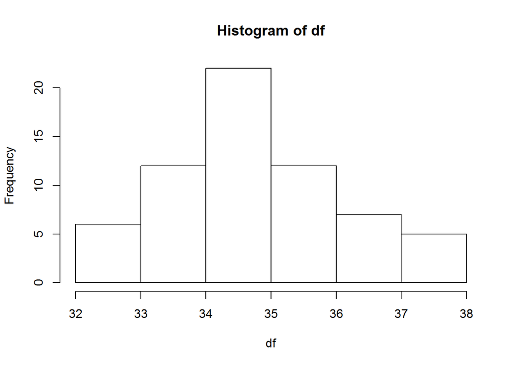

```r
hist(df)
```

#### (d) Construct a box plot of the data and comment on the information in this display.

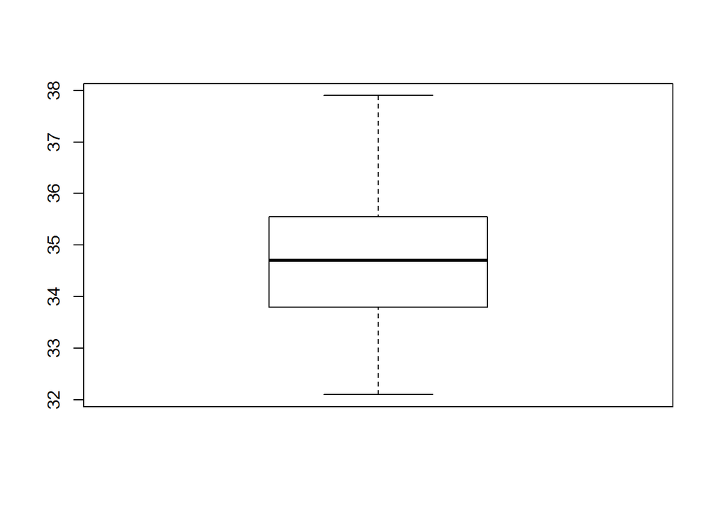

```r
boxplot(df)
```

There are no outliers in the data set. It seems to be fairly evenly spread with the second quantile being midway between the first and third quantiles. There is a slightly larger range in the upper whisker than the lower.

### Problem 2

The following data are the viscosity measurements for a chemical product observed hourly (read down, then left to right).

```r
df2 <- as.matrix(read.xlsx("HW5_data.xlsx",sheetIndex = 2))
```

#### (a) Construct and interpret either a digidot plot or a separate stem-and-leaf and time series plot of these data.

```r
stem(df2)
```

```
##
##   The decimal point is at the |
##
##   42 | 89
##   43 | 00001122235566
##   44 |
##   45 |
##   46 |
##   47 | 25999
##   48 | 0000011133345666689
```

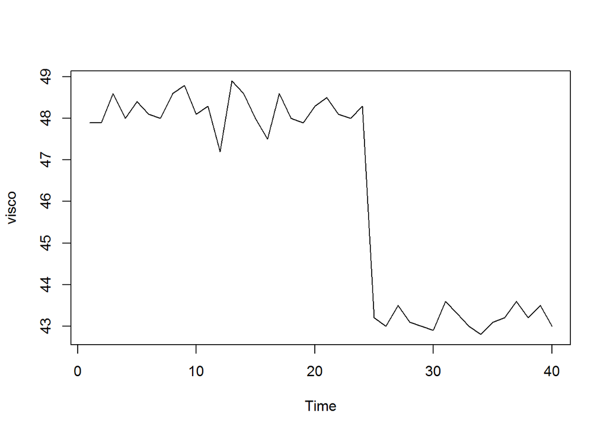

```r
plot(ts(df2))
```

The viscosity remains remotely steady around 48 until the 25 hour when it plummets drastically to an average of 43.

#### (b) Specifications on product viscosity are at 48 ± 2. What conclusions can you make about process performance?

Until the 25th hour, the process falls within the product specifications. After the 25th hour the product is no longer acceptable.

### Problem 8

Regression methods were used to analyze the data from a study investigating the relationship between roadway surface temperature (x) and pavement deflection (y). Summary quantities were:

```r
n<-20
yi<-12.7
yi2<-8.8
xi<-1487
xi2<-143215
xiyi<-1083
```

#### (a) Calculate the least squares estimates of the slope and intercept. Graph the regression line.

```r
A<-matrix(c(xi2, xi, xi, 1), 2, 2)
A
```

```
##        [,1] [,2]
## [1,] 143215 1487
## [2,]   1487    1
```

```r
B<-matrix(c(xiyi, yi),2,1)
B
```

```
##        [,1]
## [1,] 1083.0
## [2,]   12.7
```

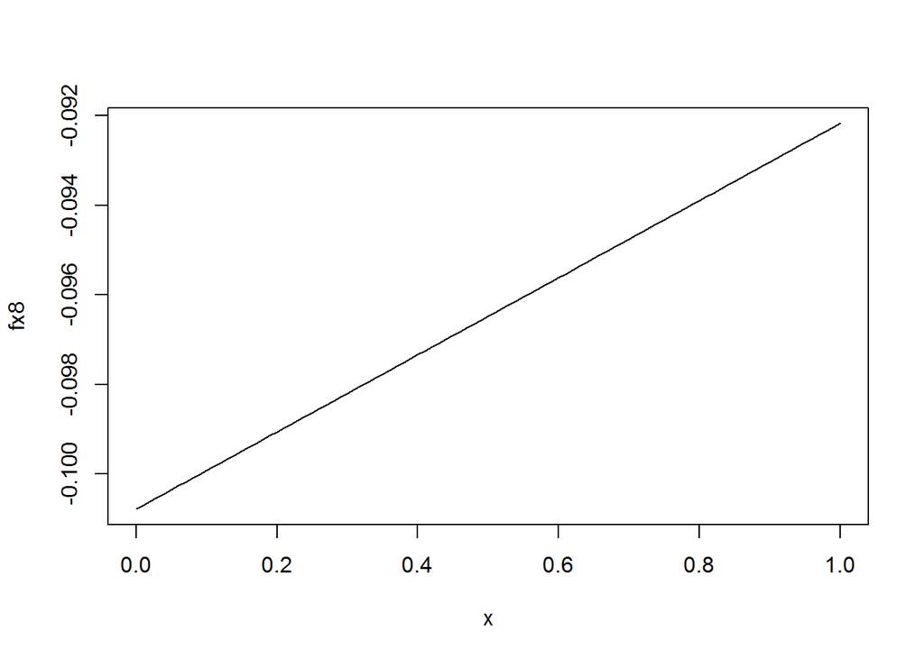

```r
c<-solve(A, B)
slope<-c[1]
intercept<-c[2]
fx8<- function(x) slope*x+intercept
plot(fx8)
```

####(b) Use the equation of the fitted line to predict what pavement deflection would be observed when the surface temperature is 85 ???F.

```r
fx8(85)
```

```
## [1] 0.6309386
```

#### (c) What is the mean pavement deflection when the surface temperature is 90???F?

```r
fx8(90)
```

```
## [1] 0.6739809
```

#### (d) What change in mean pavement deflection would be expected for a 1???F change in surface temperature?

an increase of 0.0086085 in the deflection

### Problem 9

A rocket motor is manufactured by bonding together two types of propellants, an igniter and a sustainer. The shear strength of the bond y is thought to be a linear function of the age of the propellant x when the motor is cast. Twenty observations are shown in the table below (Excel file also uploaded in D2L). ####(a) Draw a scatter diagram of the data. Does the straight-line regression model seem to be plausible? Yes, with a negative slope

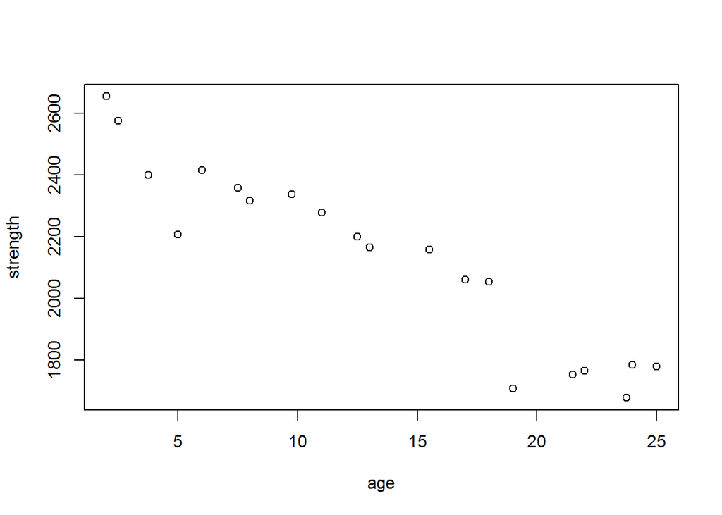

```r
strength <- as.matrix(read.xlsx("HW5_data.xlsx",sheetIndex = 3, colIndex=1) )
age <- as.matrix(read.xlsx("HW5_data.xlsx",sheetIndex = 3, colIndex=2) )
plot(age,strength)
```

```r
cor(age, strength)
```

```
##             Strength..psi.
## Age..weeks.     -0.9466156
```

#### (b) Find the least squares estimates of the slope and intercept in the simple linear regression model. Find an estimate of ??2.

```r
lmsum<-summary(lm(strength~age))
lmsum
```

```
##
## Call:
## lm(formula = strength ~ age)
##
## Residuals:
##     Min      1Q  Median      3Q     Max
## -233.08  -52.54   28.73   66.13  106.22
##
## Coefficients:
##             Estimate Std. Error t value Pr(>|t|)
## (Intercept) 2625.385     45.347   57.90  < 2e-16 ***
## age          -36.962      2.967  -12.46 2.75e-10 ***
## ---
## Signif. codes:  0 '***' 0.001 '**' 0.01 '*' 0.05 '.' 0.1 ' ' 1
##
## Residual standard error: 99.05 on 18 degrees of freedom
## Multiple R-squared:  0.8961, Adjusted R-squared:  0.8903
## F-statistic: 155.2 on 1 and 18 DF,  p-value: 2.753e-10
```

```r
sigmasq<-sum(resid(lmsum)^2)/18
sigmasq
```

```
## [1] 9811.212
```

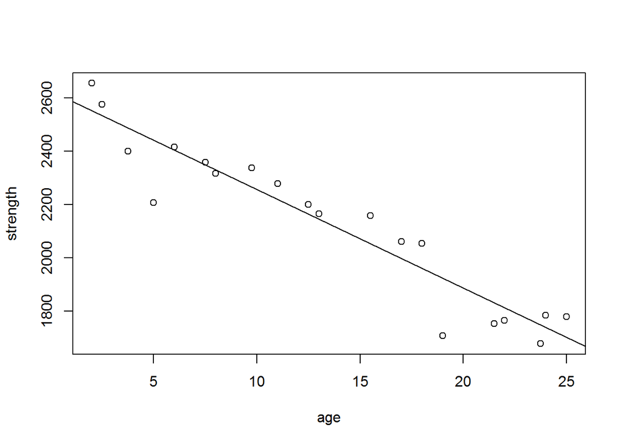

```r
fx<- function(x) -36.962*x+2625.385
plot(age,strength)
abline(lm(strength~age))
```

#### (c) Estimate the mean shear strength of a motor made from propellant that is 20 weeks old.

```r
fx(20)
```

```
## [1] 1886.145
```